# Analyse de fonctions (Introduction)

6 décembre 2016

## Plan du cours

- Généralités sur les fonctions
- Fonctions en Analyse
- Image réciproque / Image directe
- Composée
- Un peu de terminologie

## Objectifs

- Connaître le vocabulaire des fonctions
- Différencier une application et une fonction
- Reconnaître une injection/surjection/bijection

## Généralités

Soit \(A\) et \(B\) deux ensembles. Une *fonction* \(f\) est une application qui à certains éléments de \(A\) associe un élément de \(B\). On la note \(f: A \to B\)

**Exemples**

- L'application qui à chaque Français associe son numéro de carte bancaire n'est pas une fonction. **Pourquoi**?
- L'application qui à chaque Français associe son numéro de Sécurité Sociale est une fonction.
- On considère \(A\) l'ensemble des élèves de la classe et \(B=[0, 20]\). L'application qui à chaque élève associe sa note au DM de maths est une fonction.

## Vocabulaire

- \(A\) est l'*ensemble de départ* de \(f\)
- \(B\) est l'*ensemble d'arrivée* de \(f\)
- Si \(a \in A\), on note \(f(a)\) son *image* par \(f\) s'il en a une
- Si \(b \in B\), on appelle *antécédents* de \(b\) tout élément \(a \in A\) tel que \(f(a)=b\)
- L'*ensemble de définition* de \(f\), noté \(D_f\), est l'ensemble des éléments de \(A\) qui ont une image par \(f\).

## Remarques sur image et antécédent

- Attention à ne pas confondre la *fonction* \(f\) et son *expression* \(f(x)\).
- Certains éléments de \(A\) peuvent ne pas avoir d'image.
- Un élément de \(A\) **ne peut pas** avoir plusieurs images.
- Un élément de \(B\) peut avoir \(0\), \(1\) ou plusieurs antécédents.

## Les fonctions en Analyse

On appelle *suite numérique* les fonctions de \(\mathbb{N}\) dans \(\mathbb{R}\).

Soit \(u\) une suite et \(k \in \mathbb{N}\), on note \(u_k\) l'image de \(k\) par \(u\) (si elle existe). On note généralement \((u_k)\) la suite \(u\).

On appelle *fonction numérique d'une variable réelle* (souvent abrégée en fonction d'une variable ou tout simplement fonction quand le nombre de variable est explicite) les fonctions de \(A \subset \mathbb{R}\) dans \(B \subset \mathbb{R}\). On les note: \(f: \begin{cases} A & \to & B \\ x & \mapsto & f(x) \end{cases}\)

## Les fonctions de deux variables

On note \(\mathbb{R}^2\) l'ensemble des couples réels. On appelle *fonction numérique de deux variables (réelles)*les fonctions de \(A \subset \mathbb{R}^2\) dans \(B \subset \mathbb{R}\). On les note: \(f: \begin{cases} A & \to & B \\ (x, y) & \mapsto & f(x, y) \end{cases}\)

**Exemples**

- On peut naturellement étendre cette définition aux fonctions de 3, 4 et plus généralement \(n\) variables.

## Suite numérique: exemple de \(u_n = 1/n\)

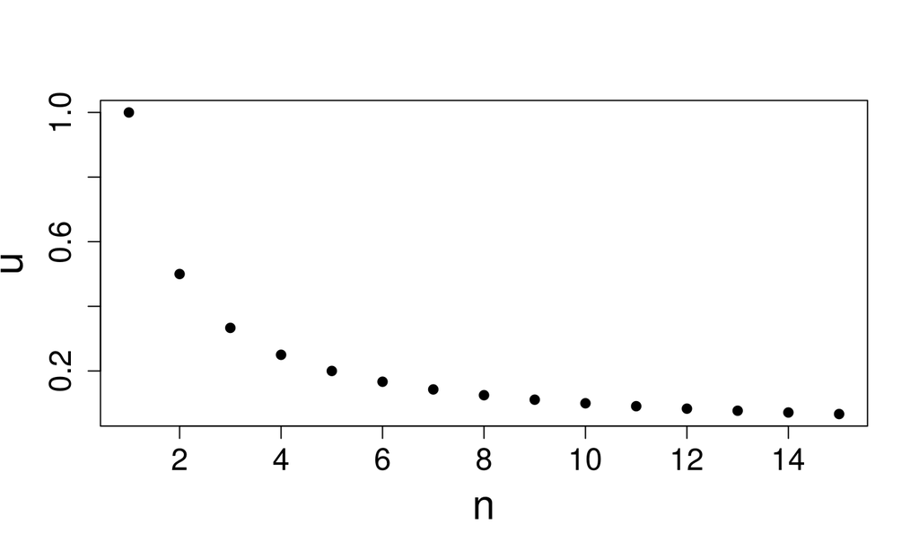

## Fonction numérique: exemple de \(f(x) = 1/x\)

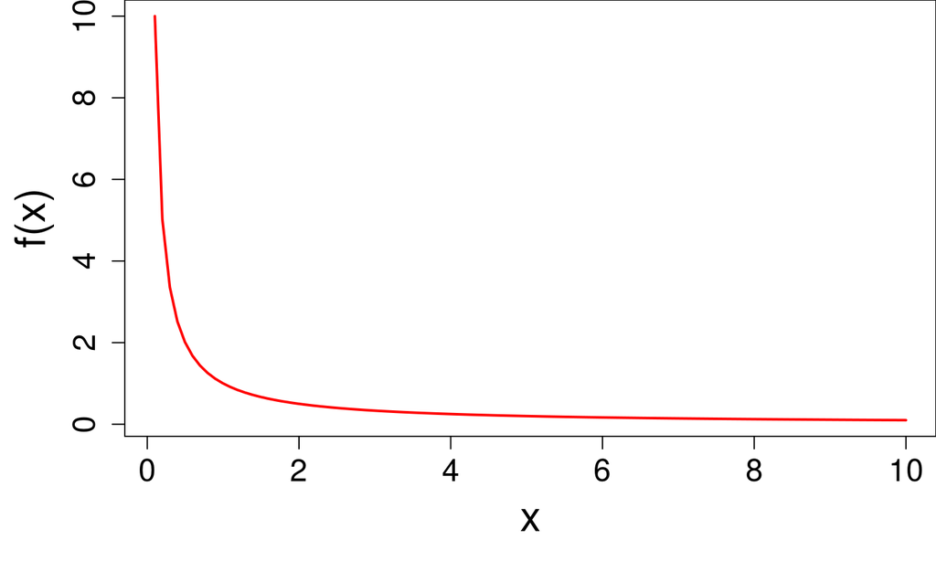

## Fonction numérique: exemple de \(f(x, y) = x^2+y^2\)

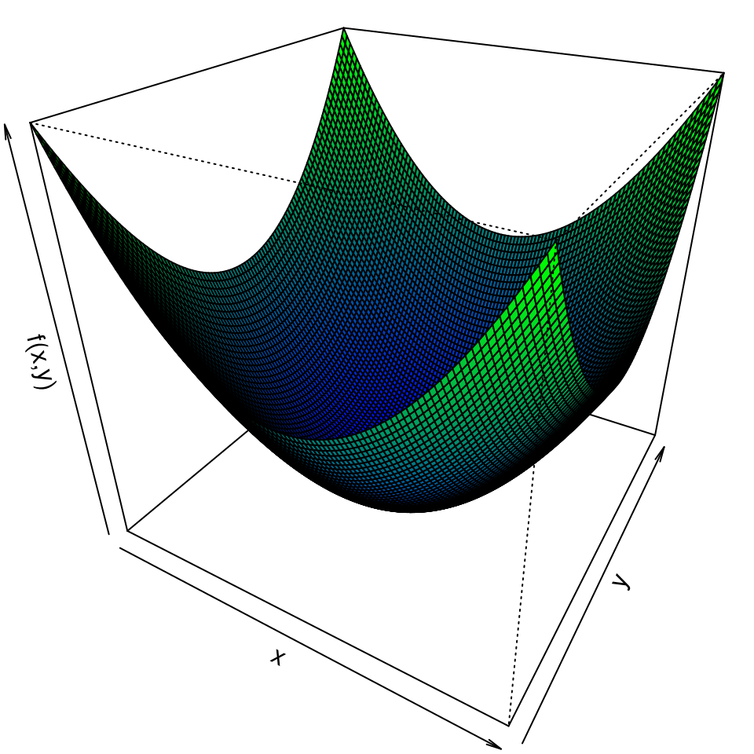

## Exercice

Soit \(f\) la fonction définie par \(f(x) = x^2\ln(x)\).

- Quel est le domaine de définition \(D_f\)?
- Quels sont les images par \(f\) de \(e\), \(1/e\), \(\sqrt{e}\), \(e^2\), \(e\sqrt{e}\), \(1/e^2\), \(1/\sqrt{e}\)?
- \(0\) a-t-il un antécédent par \(f\)?

## Image directe / Image réciproque

Soit \(f: A \to B\) une fonction.

Soit \(E \subset A\). On appelle image directe de \(E\) par \(f\) l'ensemble des images des éléments de \(E\), c'est à dire: \[\begin{align} f(E) & = \{f(e) \text{ avec } e \in E\} \\ & = \{b \in B \text{ tel qu'il existe } e \in E \text{ avec } f(e) = b\} \end{align}\]

Soit \(F \subset B\). On appelle image réciproque de \(F\) par \(f\) l'ensemble des antécédents des éléments de \(F\), c'est à dire: \[f^{-1}(E) = \{a \in A \text{ tel que } f(a) \in F\}\]

## Remarques

**Attention**

- \(f^{-1}(\{b\})\) est l'*ensemble* des antécédents de \(b\) et non **l'antécédent** qui peut ne pas exister et ne pas être unique.
- \(f^{-1}(\{b\})\) est un ensemble et pas un simple *élément* de \(A\). On rappelle que \(1\) et \(\{1\}\) ne représentent pas le même objet mathématique.

Pour trouver l'image réciproque, on revient à la définition.

- \[ x \in f^{-1}(F) \Leftrightarrow f(x) \in F \]
- \[ y \in f(E) \Leftrightarrow \exists x \in E: f(x) = y \]

## Exercices

On considère la fonction \(f\) définie par \(f(x) = x - \lfloor x \rfloor\).

- Quelle est l'image de \(0\), \(1\), \(28.5\), \([0, 1)\), \([0, 1]\), \(\mathbb{R}\)?
- Quels sont les antécédents de \(0\)? de \(1\)? de \(28.5\)?
- Quelles sont les images réciproques de \([0, 1)\)? de \([0, 1]\)? de \(\mathbb{R}\)? de \(\mathbb{N}\)?

## Composée de fonctions

Considérons 3 ensembles \(A\), \(B\), \(C\) et deux fonctions \(f: A \to B\) et \(g: B \to C\). La composée de \(g\) par \(f\) est la fonction: \[g\circ f : \begin{cases} A & \to & C \\ a & \mapsto & (g\circ f)(a) = g(f(a)) \end{cases}\]

## Exemples

Soit \(f : \begin{cases} \mathbb{R} & \to & \mathbb{R} \\ x & \mapsto & 1+x^2 \end{cases}\) et \(g : \begin{cases} \mathbb{R} & \to & \mathbb{R} \\ x & \mapsto & 1/x \end{cases}\). Alors \[g \circ f : \begin{cases} \mathbb{R} & \to & \mathbb{R} \\ x & \mapsto & \frac{1}{1+x^2} \end{cases}\]

Soit \(A\) l'ensemble des humains ayant un jour foulé la Terre. On considère \(f : \begin{cases} A & \to & A \\ x & \mapsto & \text{mère de } x \end{cases}\) et \(g : \begin{cases} A & \to & \mathbb{R} \\ x & \mapsto & \text{poids à la naissance de } x \end{cases}\).

Que vaut \(g\circ f \circ f\)?

## Applications

Soit \(f: A \to B\) une fonction. \(f\) est une application si seulement \(D_f = A\).

**Exemple**

- La fonction qui à un humain associe le prénom de son premier enfant n'est pas une application.
- \(f : \begin{cases} \mathbb{R} & \to & \mathbb{R} \\ x & \mapsto & \sqrt{x} \end{cases}\) n'est pas une application.
- \(f : \begin{cases} \mathbb{R}_+ & \to & \mathbb{R} \\ x & \mapsto & \sqrt{x} \end{cases}\) est une application.

## Restriction d'une application

Soit \(f: A \to B\) une application et \(C \subset A\) une partie de \(A\). On appelle restriction de \(f\) à \(C\) l'application: \[f_{|C} : \begin{cases} C & \to & B \\ x & \mapsto & f_{|C}(x) = f(x) \end{cases}\]

**Remarques**

- \(f_{|C}\) est bien une application
- la restriction est un mécanisme simple pour ne s'intéresser qu'à une partie de l'ensemble de départ sur laquelle \(f\) peut avoir de bonnes propriétés (injectivité, surjectivité, etc.) ou qui corespondent à des contraintes (le volume d'une bactérie doit être positif).

## Injection, Surjection, Bijection (le retour…)

Une application \(f: A \to B\) est une

- injection si et seulement tout élément \(b \in B\) admet au plus un antécédent
- surjection si et seulement tout élément \(b \in B\) admet au moins un antécédent
- bijection si et seulement tout élément \(b \in B\) admet exactement un antécédent

**Remarques**

Une bijection est une application qui est **à la fois** injective et surjective.

## Exemples

- \(f_1 : \begin{cases} \mathbb{R} & \to & \mathbb{R} \\ x & \mapsto & x^2 \end{cases}\) n'est ni injective, ni surjective
- \(f_2 : \begin{cases} \mathbb{R} & \to & \mathbb{R}_+ \\ x & \mapsto & x^2 \end{cases}\) est surjective mais pas injective
- \(f_3 : \begin{cases} \mathbb{R}_+ & \to & \mathbb{R} \\ x & \mapsto & x^2 \end{cases}\) est injective mais pas surjective
- \(f_4 : \begin{cases} \mathbb{R}_+ & \to & \mathbb{R}_+ \\ x & \mapsto & x^2 \end{cases}\) est bijective
- Le code génétique (vu comme une application des codons dans les acides aminés) est surjectif mais pas injectif.

**Remarques** Le caractère injective/surjective **dépend** des ensembles d'arrivée et de départ, attention à les préciser.

## Fonction réciproque

Soit \(f: A \to B\) une application. \(f\) est bijective si et seulement si il existe une application \(g: B \to A\), appelée réciproque de \(f\) et souvent noté \(f^{-1}\), telle que \[ \forall a \in A, g\circ f(a) = a \quad \text{ et } \quad \forall b \in B, f\circ g(b) = b \]

Soit \(A\) un ensemble. On note \(Id_A\) l'application identité de \(A\): \(f : \begin{cases} A & \to & A \\ a & \mapsto & a \end{cases}\)

\(f: A \to B\) est une bijection si et seulement si il existe une application \(g: B \to A\) telle que \(g\circ f = Id_A\) et \(f\circ g = Id_B\)

## Fonctions monotones

Soit \(f: A \subset \mathbb{R} \to \mathbb{R}\) une application. Si \(f\) est strictement croissante (ou strictement décroissante), alors \(f\) est injective. Elle est aussitôt bijective de \(A\) sur \(f(A)\).

**Remarques** Les bijections ont un intérêt particulier en mathématiques, elles permettent de travailler sur des éléments de \(A\) (élèves scolarisés à Paris Descartes) ou \(B\) (numéro d'étudiant) indifféremment et **sans perte d'information**. En particulier, il y *autant* d'éléments dans \(A\) que dans \(B\) et \(f\) (respectivement \(f^{-1}\)) fournit une façon non ambigüe de passer de \(A\) à \(B\) (de \(B\) à \(A\))

## Exercice récapitulatif (I)

Soit \(f: \begin{cases} \mathbb{R} & \to & \mathbb{R} \\ x & \mapsto & e^{x^2+x+1} \end{cases}\).

- \(f\) est-elle une application?
- Déterminer \(f(\mathbb{R})\), \(f^{-1}(\mathbb{R})\), \(f^{-1}(\mathbb{R}_+^\star)\), \(f^{-1}([0, 1)\)
- \(f\) est-elle une bijection de \(\mathbb{R}\) sur \(\mathbb{R}\)?
- \(f\) est-elle une bijection de \(\mathbb{R}\) sur \(f(\mathbb{R})\)?
- Montrer que \(f\) est une bijection de \(\mathbb{R}_+\) sur un intervalle \(I\) à préciser.

## Exercice récapitulatif (II)

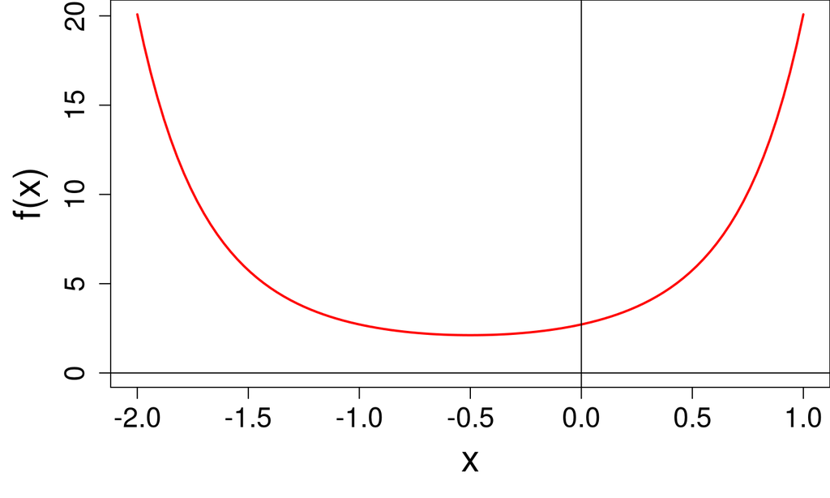